# Database Analyses Script

Narayan S

25 January 2016

# Introduction

This document details the database analyses steps for each habitat (reefs, mangroves, marshes and grasses), including: a) variable definitions; b) meta-analyses of wave height reduction; c) analyses of project data, costs, benefits, distance to measurement sites and cost-effectiveness; d) plots of measurement and project locations, cost-effectiveness curves and wave height response curves.

# Script

## Libraries

```r
library(ggplot2)
library(relaimpo)
library(rgdal)
library(ggmap)
library(dplyr)
library(tidyr)
library(magrittr)
library(maps)
library(mapdata)
library(rworldmap)
require(gridExtra) # for plotting multiple plots
```

## Data Input and Dataframe Transformations

Here we read data from the field measurements (“wavereduction.txt”) and the project reports (“projectdata.txt”), and do the following:  
1. For the wave reduction data  
+ calculate values of dimensionless variables of interest in the wave reduction response analyses  
+ reclassify all reef habitats into a single group  
2. For the project data  
+ estimate mean and total costs, if a range of costs are reported  
+ convert costs to 2014 USD using CPI indices from the table  
+ rename habitats  
+ create subsets of projects that: a)report location; b)report Benefit data, and/or c)report Cost data  
+ calculate mean unit restoration costs and project areas, with Confidence Intervals, for each habitat type and store these in a separate variable  
+ store some of these values in a variable “meanvals” for writing to an output file

```r
alldata<-read.table("C:/Rfiles/SNAP/WaveReductionData_20150902.txt", header = TRUE, sep="\t")
costdata<-read.table("C:/Rfiles/SNAP/Projectdata_20151117.txt", header = TRUE)
alldata<-alldata %>%
  mutate(
    hvbyh=hv/h,
    Hbyh=HsC/h,
    HbyB=HsC/B,
    HabitatGrp=ifelse(Habitat=="CRC"|Habitat=="CRF"|Habitat=="CRW","CR",as.character(Habitat))
  )
costdata<-costdata %>%
  mutate(
    Reported.Cost.Mean=ifelse(Reported.Cost.V2==0.0,Reported.Cost.V1,((Reported.Cost.V1+Reported.Cost.V2)/2)),
    Habitat.Cost.Reported.Total=ifelse(Cost.Unit=="Total",Reported.Cost.Mean,
                                       ifelse(Cost.Unit=="Ha",Reported.Cost.Mean*(Area/10000),
                                              Reported.Cost.Mean*Area)),
    Habitat.Cost.USD2014=Habitat.Cost.Reported.Total*CPI.2014*USD.2014,
    Habitat.Cost.Per.SquareMeter=Habitat.Cost.USD2014 / Area,
    HabitatName=ifelse(Habitat=="CR","Coral Reef",ifelse(Habitat=="OR","Oyster Reef",ifelse(Habitat=="SM","Salt Marsh","Mangrove")))
  )

projdata<-subset(costdata, costdata$Latitude!="NaN")
bencostdata<-subset(costdata, Benefit.Type!="NaN")
creationcostdata<-subset(costdata,costdata$Habitat.Cost.Per.SquareMeter!="NaN")

creationcostdata<-group_by(creationcostdata, HabitatName)
meanvals<-creationcostdata %>%
  mutate(
    MeanUnitCost=mean(Habitat.Cost.Per.SquareMeter),
    Cost95Upper=MeanUnitCost+sd(Habitat.Cost.Per.SquareMeter)*1.96/sqrt(length(HabitatName)),
    Cost95Lower=MeanUnitCost-sd(Habitat.Cost.Per.SquareMeter)*1.96/sqrt(length(HabitatName)),
    MeanArea=mean(Area),
    Area95Upper=MeanArea+sd(Area)*1.96/sqrt(length(HabitatName)),
    Area95Lower=MeanArea-sd(Area)*1.96/sqrt(length(HabitatName))
    )
creationcostdata<-ungroup(creationcostdata)
meanvals<-meanvals %>%
  dplyr::select(HabitatName, MeanUnitCost, Cost95Upper, Cost95Lower, MeanArea, Area95Upper, Area95Lower) %>%
  distinct(HabitatName)
```

## Variable Definitions

Here we define new variables outside the datasets, as required for the meta-analyses, regression analyses and plots

```r
wvdata<-subset(alldata,alldata$HsC!=-999)
reefdata<-subset(wvdata, wvdata$HabitatGrp=="CR")
vegdata<-subset(wvdata, wvdata$HabitatGrp!="CR")
itvegdata<-subset(vegdata, vegdata$Habitat!="SG") # much better than grep() for subsetting! Note: Can use use %in% for multiple strings
mgdata<-subset(vegdata, vegdata$Habitat=="MG")
smdata<-subset(vegdata, vegdata$Habitat=="SM")
sgdata<-subset(vegdata, vegdata$Habitat=="SG")
mgdata_submerge<-subset(mgdata, mgdata$alpha<=1)
mgdata_emerge<-subset(mgdata, mgdata$alpha>1)
smdata_submerge<-subset(smdata, smdata$alpha<1)
smdata_emerge<-subset(smdata, smdata$alpha>1)
reefdata_noXoutlier<-subset(reefdata, reefdata$X<50)
mgdata_noXoutlier<-subset(mgdata, mgdata$X<50)
#Estimating median widths
reefdata_Border<-reefdata[order(reefdata$B),]
reef_B_median<-median(reefdata_Border$B,na.rm=TRUE)
mgdata_Border<-mgdata[order(mgdata$B),]
mg_B_median<-median(mgdata_Border$B,na.rm=TRUE)
smdata_Border<-smdata[order(smdata$B),]
sm_B_median<-median(smdata_Border$B,na.rm=TRUE)
sgdata_Border<-sgdata[order(sgdata$B),]
sg_B_median<-median(sgdata_Border$B,na.rm=TRUE)
```

## Meta-Analyses of Wave Height Reduction

### Random Effects Model

#### Using Eq 4.19, Eq 12.6, Eq 11.2 in Borenstein, 2009

Here we create a function for meta-analyses of wave height reduction measurements, for each habitat, to measure the effect size, R, defined as the ratio of the wave height after the habitat to the wave height before the habitat. The function is evaluated separately for each habitat type. We also create a table “meanRRvals” for writing to an output file.

```r
meta_analyses <- function(habitat) {
  habitat %>%
    mutate(
      RR=HsT/HsC,
      Yi=log(RR), #Effect size
      Vyi=(HsCErr^2)/(n*HsC^2)+(HsTErr^2)/(n*HsT^2), # Eq 4.19 for Swithin from Borenstein
      Wi=1/Vyi,
      Wi2=Wi^2,
      Wi.Yi=Wi*Yi,
      Wi.Yi2=Wi*Yi^2,
      df=nrow(reefdata)-1,
      Q=sum(Wi.Yi2)-((sum(Wi.Yi))^2/sum(Wi)),
      C=sum(Wi)-sum(Wi2)/sum(Wi),
      T2=(Q-df)/C,
      Vyi_star=Vyi+T2,
      Wi_star=1/Vyi_star,
      Wi_star.Yi=Wi_star*Yi,
      r=(1-RR)/B,
      M_star=sum(Wi_star.Yi)/sum(Wi_star),
      Vm_star=1/sum(Wi_star),
      Sem_star=sqrt(Vm_star),
      Z_star=M_star/Sem_star,
      MeanRR=100*(1-exp(M_star)),
      LLm=100*(1-exp(M_star-1.96*Sem_star)),
      ULm=100*(1-exp(M_star+1.96*Sem_star)),
      MeanRR_energy=(1-(1-MeanRR/100)^2)*100,
      LLm_energy=(1-(1-LLm/100)^2)*100,
      ULm_energy=(1-(1-ULm/100)^2)*100
    )
}

meta_reefs<-meta_analyses(reefdata)
meta_marshes<-meta_analyses(smdata)
meta_mangroves<-meta_analyses(mgdata)
meta_grasses<-meta_analyses(sgdata)

meanRRvals=data.frame(matrix(NA,ncol=8,nrow=4))
colnames(meanRRvals)<-c("Habitat","Mean Wave Height Reduction %","95% CI Lower", "95% CI Upper","Mean Wave Energy Reduction %","95% CI Lower (Energy)","95% CI Upper (Energy)","Average Measured Wave Height (m)")
meanRRvals[1:4,1]=c("Coral Reefs","Salt_Marshes","Mangroves","Seagrass/Kelp Beds")
meanRRvals[1:4,2]=c(mean(meta_reefs$MeanRR),mean(meta_marshes$MeanRR),mean(meta_mangroves$MeanRR),mean(meta_grasses$MeanRR))
meanRRvals[1:4,3]=c(mean(meta_reefs$ULm),mean(meta_marshes$ULm),mean(meta_mangroves$ULm),mean(meta_grasses$ULm))
meanRRvals[1:4,4]=c(mean(meta_reefs$LLm),mean(meta_marshes$LLm),mean(meta_mangroves$LLm),mean(meta_grasses$LLm))
meanRRvals[1:4,5]=c(mean(meta_reefs$MeanRR_energy),mean(meta_marshes$MeanRR_energy),mean(meta_mangroves$MeanRR_energy),mean(meta_grasses$MeanRR_energy))
meanRRvals[1:4,6]=c(mean(meta_reefs$ULm_energy),mean(meta_marshes$ULm_energy),mean(meta_mangroves$ULm_energy),mean(meta_grasses$ULm_energy))
meanRRvals[1:4,7]=c(mean(meta_reefs$LLm_energy),mean(meta_marshes$LLm_energy),mean(meta_mangroves$LLm_energy),mean(meta_grasses$LLm_energy))
meanRRvals[1:4,8]=c(mean(reefdata$HsC),mean(smdata$HsC),mean(mgdata$HsC),mean(sgdata$HsC))
meanRRvals
```

```
##              Habitat Mean Wave Height Reduction % 95% CI Lower
## 1        Coral Reefs                     70.23534     53.68648
## 2       Salt_Marshes                     71.82197     62.07648
## 3          Mangroves                     30.99536     25.29368
## 4 Seagrass/Kelp Beds                     36.00321     27.36859
##   95% CI Upper Mean Wave Energy Reduction % 95% CI Lower (Energy)
## 1     80.87092                     91.14065              78.55058
## 2     79.06309                     92.05999              85.61807
## 3     36.26188                     52.38359              44.18965
## 4     43.61132                     59.04411              47.24678
##   95% CI Upper (Energy) Average Measured Wave Height (m)
## 1              96.34078                        0.7855882
## 2              95.61646                        0.3263103
## 3              59.37452                        0.3646249
## 4              68.20317                        0.5384383
```

## Project Data Analyses

### Estimating distances to field measurements and site conditions for all nearby projects

Here we do two pieces of analyses:  
1. Subset all beneficial projects that are within a specified distance (in this case 50 km) of a recorded field measurement site, to use later in a global plot  
2. Subset all projects that report cost data and are within 50 km For each unique pair of nearby projects and field measurements we create a new set of Nature-based Defense (NbD) projects that have area, cost and benefit data from the project site and wave, wave reduction, water level and habitat data from the field measurement site.

```r
for(i in 1:length(bencostdata$ID))
{
  for (j in 1:length(alldata$ID))
  {
    if((abs(alldata$Latitude[j]-bencostdata$Latitude[i])<=0.46)&&(abs(alldata$Longitude[j]-bencostdata$Longitude[i])<=0.46)&&(alldata$R[j]>0))
    {
      bencostdata$NearbyExp[i]="Yes"
      break
    }


    else
      bencostdata$NearbyExp[i]="No"

  }
}

nearbyprojects<-data.frame(matrix(NA,ncol=23,nrow=length(alldata$ID)))
colnames(nearbyprojects)<-c("Proj_ID","Exp_ID","Proj_Study","Exp_Study","Habitat","Country","Proj_lat","Proj_lon","Exp_lat","Exp_lon","Proj_area","Proj_width","Exp_width","Exp_depth","Exp_Hs","Exp_Tp","Exp_R","Exp_R_per_m","Exp_r","Proj_cost_m2","Proj_B_type","Proj_Rpercent","Proj_cost_per_m2")
k=0
for(i in 1:length(projdata$ID)) {
  for (j in 1:length(alldata$ID)) {
    deltaLat<-abs(alldata$Latitude[j]-projdata$Latitude[i])* pi/180
    deltaLon<-abs(alldata$Longitude[j]-projdata$Longitude[i])* pi/180
    x=deltaLon*cos((alldata$Latitude[j]*pi/180+projdata$Latitude[i]*pi/180)/2)
    y=deltaLat
    distance=6371*sqrt(x*x+y*y)
    if((distance<=50)&&(alldata$R[j]>0))
    {
      k=k+1
      nearbyprojects$Proj_ID[k]<-projdata$ID[i]
      nearbyprojects$Exp_ID[k]<-alldata$ID[j]
      nearbyprojects$Proj_Study[k]<-as.character(projdata$First_Author[i])
      nearbyprojects$Exp_Study[k]<-as.character(alldata$First_Author[j])
      nearbyprojects$Habitat[k]<-as.character(projdata$HabitatName[i])
      nearbyprojects$Country[k]<-as.character(projdata$Country[i])
      nearbyprojects$Proj_lat[k]<-as.numeric(projdata$Latitude[i])
      nearbyprojects$Proj_lon[k]<-as.numeric(projdata$Longitude[i])
      nearbyprojects$Exp_lat[k]<-as.numeric(alldata$Latitude[j])
      nearbyprojects$Exp_lon[k]<-as.numeric(alldata$Longitude[j])
      nearbyprojects$Proj_area[k]<-as.numeric(projdata$Area[i])
      nearbyprojects$Proj_width[k]<-as.numeric(projdata$Width[i])
      nearbyprojects$Exp_width[k]<-as.numeric(alldata$B[j])
      nearbyprojects$Exp_depth[k]<-as.numeric(alldata$h[j])
      nearbyprojects$Exp_Hs[k]<-as.numeric(alldata$HsC[j])
      nearbyprojects$Exp_Tp[k]<-as.numeric(alldata$Tp[j])
      nearbyprojects$Exp_R[k]<-as.numeric(alldata$R[j])
      nearbyprojects$Exp_R_per_m[k]<-as.numeric(alldata$R[j]/alldata$B[j])
      nearbyprojects$Exp_r[k]<-as.numeric(alldata$r[j]) # This r = R/B = r-actual/Hi
      nearbyprojects$Proj_cost_m2[k]<-as.numeric(projdata$Habitat.Cost.Per.SquareMeter[i])
      nearbyprojects$Proj_B_type[k]<-as.character(projdata$Benefit.Type[i])
    }
  }}
nearbyprojects<-nearbyprojects[order(nearbyprojects$Proj_ID, -nearbyprojects$Exp_R),]
```

## Estimate cost and wave reduction effectiveness of new set of NbD projects

Here we first estimate the unit restoration costs and total wave reduction of the NbD projects (that have nearby field measurements) and then estimate the construction costs of a submerged breakwater to achieve the same wave reduction under the same site conditions. All these projects are either mangroves or salt-marshes.

```r
#NbD Project restoration costs and wave reduction extents
nearbyprojects<-filter(nearbyprojects,Proj_width>1&Proj_width!="NA")
nearbyprojects<-filter(nearbyprojects,Exp_Hs!=1)
nearbyprojects<-nearbyprojects %>%
  mutate(
    NbD_Kt=ifelse((1-Exp_r*Proj_width)>0.05,1-Exp_r*Proj_width,0.05),
    NbD_RPercent=(1-NbD_Kt^2)*100,
    Proj_Rpercent=ifelse((Exp_R*100*Proj_width/Exp_width)<100,Exp_R*100*Proj_width/Exp_width,100),
    Proj_cost_per_m=Proj_cost_m2*Proj_width
    )
nearbyprojects<-filter(nearbyprojects, Proj_cost_per_m!="NA")

#Structure dimensions and costs (based on USACE reports and manuals)
slope=1/100 #bottom slope
repstrucvol=36.288 #m3 per m of cross-section from NACCS Appendix T, Fig II-10
repstruccost=27600 #US$ per mfrom NACCS Appendix T, Table II-10
unitcost_NACCS=repstruccost/repstrucvol #cost per m3 per m for USA from NACCS Report Appendix T, Section II.4
struc_slope=1.5 #from NACCS Appendix T, Fig II-10

struct_comparison<-nearbyprojects[c("Proj_ID","Exp_ID","Country","Habitat","Proj_width","Exp_depth","Exp_Hs","Exp_Tp","Exp_R_per_m","Proj_Rpercent","Proj_cost_per_m")]
colnames(struct_comparison)<-c("Proj_ID","Exp_ID","Country","Habitat","Proj_width","Proj_depth","Hs","Tp","Proj_R_per_m","Proj_R_Total","Proj_cost_per_m")
struct_comparison<-struct_comparison %>%
  mutate(
    Struc_depth=ifelse(Proj_depth!="NaN",Proj_depth,1),
    Proj_Kt=ifelse((1-Proj_R_per_m*Proj_width)>0,1-Proj_R_per_m*Proj_width,0.05),
    SSP=tan(slope)/sqrt(Hs*2*pi/(9.81*Tp*Tp)),
    Struc_Rc=as.numeric(c(-0.075,-0.021,-0.032,-0.55,-0.055,-0.12,-0.012,-0.012,-0.023,-0.014,-0.016,-0.021,-0.032)), #based on formulae for desired Kt
    Struc_Bc=as.numeric(c(2,4,4,4,6,2,2,2,6,6,2,4,4)), #based on formulae for desired Kt
    Struc_Kt=ifelse(Struc_Bc/Hs>12,(Struc_Kt=-0.35*Struc_Rc/Hs+0.51*(1-exp(-0.41*SSP))/((Struc_Bc/Hs)^0.65)),(Struc_Kt=-0.4*Struc_Rc/Hs+0.64*(1-exp(-0.41*SSP))/((Struc_Bc/Hs)^0.31))),
    Struc_Ht=Struc_depth+Struc_Rc,
    Struc_vol=(Struc_Ht*(Struc_Bc+Struc_Bc+Struc_Ht*struc_slope)/2),
    Struc_cost_per_m=ifelse((Country=="Vietnam"|Country=="China"),Struc_vol*unitcost_NACCS/10,Struc_vol*unitcost_NACCS),
    RCratio=Struc_cost_per_m/Proj_cost_per_m,
    Struc_max_effective_unitcost_per_m=Proj_cost_per_m/Struc_vol,
    BeneficialProj_cost_per_m=Proj_cost_per_m/RCratio,
    Kt_Family=as.numeric(ifelse(Proj_Kt==0.05,100,ifelse(Proj_Kt<0.25,75,ifelse(Proj_Kt<0.5,50,25))))
    )
struct_comparison<-struct_comparison %>%
  group_by(Proj_width) %>%
  mutate(
    WidthAvg_RCratio=mean(RCratio)
    ) %>%
  ungroup() # Remember to ungroup!
```

Next, we estimate the dimensions and costs of breakwaters across a range of transmission coefficients, for all the wave and water level conditions at the project sites, to develop cost curves for the replacement submerged breakwaters. We also estimate the value of the replacement structure for each project’s habitat.

```r
Kt_All<-struct_comparison %>%
  distinct(Proj_depth,Proj_width) %>%
  select(Proj_ID, Country, Habitat, Proj_width, Proj_depth, Hs, Struc_Bc, Proj_cost_per_m,Proj_R_Total, Struc_max_effective_unitcost_per_m, Kt_Family) %>%
  arrange(Proj_depth)
Kt_Struc<-Kt_All %>%
  distinct(Proj_depth) %>%
  mutate(
    #Kt = 0.05, ## Rc Estimated for given depth and Hs, for Kt=0.05
    Rc0.05=as.numeric(c(-0.01,-0.015,-0.01,-0.012,-0.015,-0.015)),
        Ht0.05=Proj_depth+Rc0.05,
    Vol0.05=(Ht0.05*(Struc_Bc+Struc_Bc+Ht0.05*struc_slope)/2),
    Struc_cost_0.05=Vol0.05*unitcost_NACCS,
    #Kt = 0.25,  ## Rc Estimated for given depth and Hs, for Kt=0.25
    Rc0.25=as.numeric(c(-0.14,-0.105,-0.16,-0.072,-0.115,-0.08)),
    Ht0.25=Proj_depth+Rc0.25,
    Vol0.25=(Ht0.25*(Struc_Bc+Struc_Bc+Ht0.25*struc_slope)/2),
    Struc_cost_0.25=Vol0.25*unitcost_NACCS,
    #Kt = 0.5, ## Rc Estimated for given depth and Hs, for Kt=0.5
    Rc0.5=as.numeric(c(-0.3,-0.215,-0.35,-0.145,-0.24,-0.165)),
    Ht0.5=Proj_depth+Rc0.5,
    Vol0.5=(Ht0.5*(Struc_Bc+Struc_Bc+Ht0.5*struc_slope)/2),
    Struc_cost_0.5=Vol0.5*unitcost_NACCS,
    #Kt = 0.75, ## Rc Estimated for given depth and Hs, for Kt=0.75
    Rc0.75=as.numeric(c(-0.465,-0.33,-0.535,-0.22,-0.365,-0.247)),
    Ht0.75=Proj_depth+Rc0.75,
    Vol0.75=(Ht0.75*(Struc_Bc+Struc_Bc+Ht0.75*struc_slope)/2),
    Struc_cost_0.75=Vol0.75*unitcost_NACCS,
    #Kt = 0.05 & Hs=0.1 & Bc=2,  ## Rc Estimated for all depths, for Kt=0.05, Hs = 0.1
    Rc0.05_Hs0.1_Bc2=as.numeric(c(-0.012,-0.012,-0.012,-0.012,-0.012,-0.012)),
    Ht0.05_Hs0.1_Bc2=Proj_depth+Rc0.05_Hs0.1_Bc2,
    Vol0.05_Hs0.1_Bc2=(Ht0.05_Hs0.1_Bc2*(2+2+Ht0.05_Hs0.1_Bc2*struc_slope)/2),
    StrucCost0.05_Hs0.1_Bc2=Vol0.05_Hs0.1_Bc2*unitcost_NACCS,
    #Kt = 0.75 & Hs=0.1 & Bc=2,  ## Rc Estimated for all depths, for Kt=0.75, Hs = 0.1
    Rc0.75_Hs0.1_Bc2=as.numeric(c(-0.213,-0.213,-0.213,-0.213,-0.213,-0.213)),
    Ht0.75_Hs0.1_Bc2=Proj_depth+Rc0.75_Hs0.1_Bc2,
    Vol0.75_Hs0.1_Bc2=(Ht0.75_Hs0.1_Bc2*(2+2+Ht0.75_Hs0.1_Bc2*struc_slope)/2),
    StrucCost0.75_Hs0.1_Bc2=Vol0.75_Hs0.1_Bc2*unitcost_NACCS,
    #Kt = 0.05 & Hs=0.2 & Bc=2,  ## Rc Estimated for all depths, for Kt=0.05, Hs = 0.2
    Rc0.05_Hs0.2_Bc2=as.numeric(c(-0.015,-0.015,-0.015,-0.015,-0.015,-0.015)),
    Ht0.05_Hs0.2_Bc2=Proj_depth+Rc0.05_Hs0.2_Bc2,
    Vol0.05_Hs0.2_Bc2=(Ht0.05_Hs0.2_Bc2*(2+2+Ht0.05_Hs0.2_Bc2*struc_slope)/2),
    StrucCost0.05_Hs0.2_Bc2=Vol0.05_Hs0.2_Bc2*unitcost_NACCS,
    #Kt = 0.75 & Hs=0.2 & Bc=2,  ## Rc Estimated for all depths, for Kt=0.75, Hs = 0.2
    Rc0.75_Hs0.2_Bc2=as.numeric(c(-0.39,-0.39,-0.39,-0.39,-0.39,-0.39)),
    Ht0.75_Hs0.2_Bc2=Proj_depth+Rc0.75_Hs0.2_Bc2,
    Vol0.75_Hs0.2_Bc2=(Ht0.75_Hs0.2_Bc2*(2+2+Ht0.75_Hs0.2_Bc2*struc_slope)/2),
    StrucCost0.75_Hs0.2_Bc2=Vol0.75_Hs0.2_Bc2*unitcost_NACCS,
    #Kt = 0.05 & Hs=0.3 & Bc=2,  ## Rc Estimated for all depths, for Kt=0.05, Hs = 0.3
    Rc0.05_Hs0.3_Bc2=as.numeric(c(-0.01,-0.01,-0.01,-0.01,-0.01,-0.01)),
    Ht0.05_Hs0.3_Bc2=Proj_depth+Rc0.05_Hs0.3_Bc2,
    Vol0.05_Hs0.3_Bc2=(Ht0.05_Hs0.3_Bc2*(2+2+Ht0.05_Hs0.3_Bc2*struc_slope)/2),
    StrucCost0.05_Hs0.3_Bc2=Vol0.05_Hs0.3_Bc2*unitcost_NACCS,
    #Kt = 0.75 & Hs=0.3 & Bc=2,  ## Rc Estimated for all depths, for Kt=0.75, Hs = 0.3
    Rc0.75_Hs0.3_Bc2=as.numeric(c(-0.53,-0.53,-0.53,-0.53,-0.53,-0.53)),
    Ht0.75_Hs0.3_Bc2=Proj_depth+Rc0.75_Hs0.3_Bc2,
    Vol0.75_Hs0.3_Bc2=(Ht0.75_Hs0.3_Bc2*(2+2+Ht0.75_Hs0.3_Bc2*struc_slope)/2),
    StrucCost0.75_Hs0.3_Bc2=Vol0.75_Hs0.3_Bc2*unitcost_NACCS
    )
Kt_All<-Kt_All %>%
  arrange(-Kt_Family) %>%
  mutate(
    Kt_Family=as.character(Kt_Family)
    )
Kt_Mangrove<-filter(Kt_All,Habitat=="Mangrove")
Kt_SaltMarsh<-filter(Kt_All,Habitat!="Mangrove")

mg_struc_maxunitcost_mean<-mean(Kt_Mangrove$Struc_max_effective_unitcost_per_m)
sm_struc_maxunitcost_mean<-mean(Kt_SaltMarsh$Struc_max_effective_unitcost_per_m)
mg_struc_maxunitcost_sd<-sd(Kt_Mangrove$Struc_max_effective_unitcost_per_m)
sm_struc_maxunitcost_sd<-sd(Kt_SaltMarsh$Struc_max_effective_unitcost_per_m)
mg_struc_maxunitcost_margin<-qt(0.975,length(Kt_Mangrove)-1)*mg_struc_maxunitcost_sd/sqrt(length(Kt_Mangrove))
sm_struc_maxunitcost_margin<-qt(0.975,length(Kt_SaltMarsh)-1)*sm_struc_maxunitcost_sd/sqrt(length(Kt_SaltMarsh))

struceffcostvals=data.frame(matrix(NA,ncol=4,nrow=2))
colnames(struceffcostvals)<-c("Habitat","Structural Replacement value (per m3 per m)","95% CI Upper", "95% CI Lower")
struceffcostvals[1:2,1]=c("Mangrove","Salt-Marsh")
struceffcostvals[1:2,2]=c(mg_struc_maxunitcost_mean,sm_struc_maxunitcost_mean)
struceffcostvals[1:2,3]=c(mg_struc_maxunitcost_mean-mg_struc_maxunitcost_margin, sm_struc_maxunitcost_mean-sm_struc_maxunitcost_margin)
struceffcostvals[1:2,4]=c(mg_struc_maxunitcost_mean+mg_struc_maxunitcost_margin, sm_struc_maxunitcost_mean+sm_struc_maxunitcost_margin)
struceffcostvals
```

```
##      Habitat Structural Replacement value (per m3 per m) 95% CI Upper
## 1   Mangrove                                    18.49806     9.546728
## 2 Salt-Marsh                                   742.82085   377.501279
##   95% CI Lower
## 1      27.4494
## 2    1108.1404
```

## Plots

Now we plot.

First we plot the cost curves just estimated versus all NbD project water depths, alongside the project wave reduction extents, and by habitat.

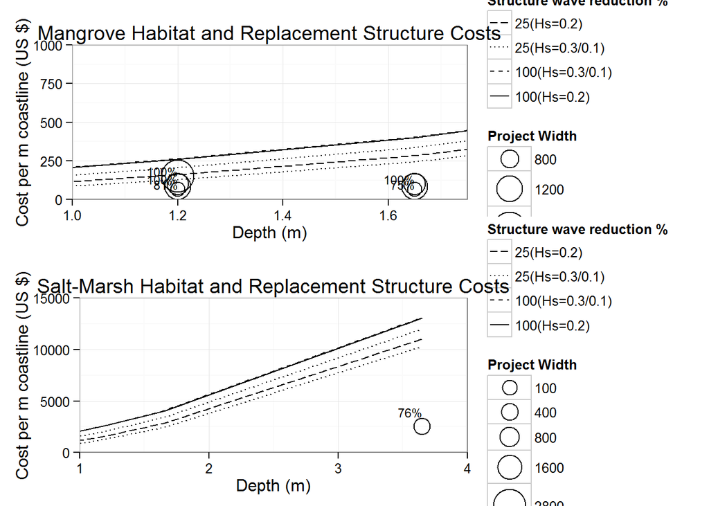

Next we plot the global map of field measurement and project sites, showing extents of wave reduction and only projects that report benefits.

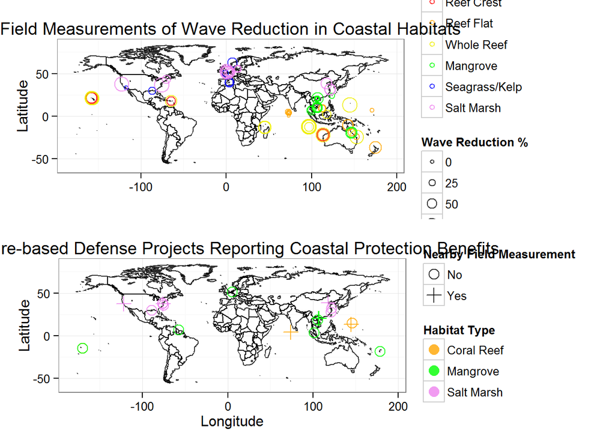

Next we plot the meta-analyses results in the order:  
1. Wave reduction % versus habitat width

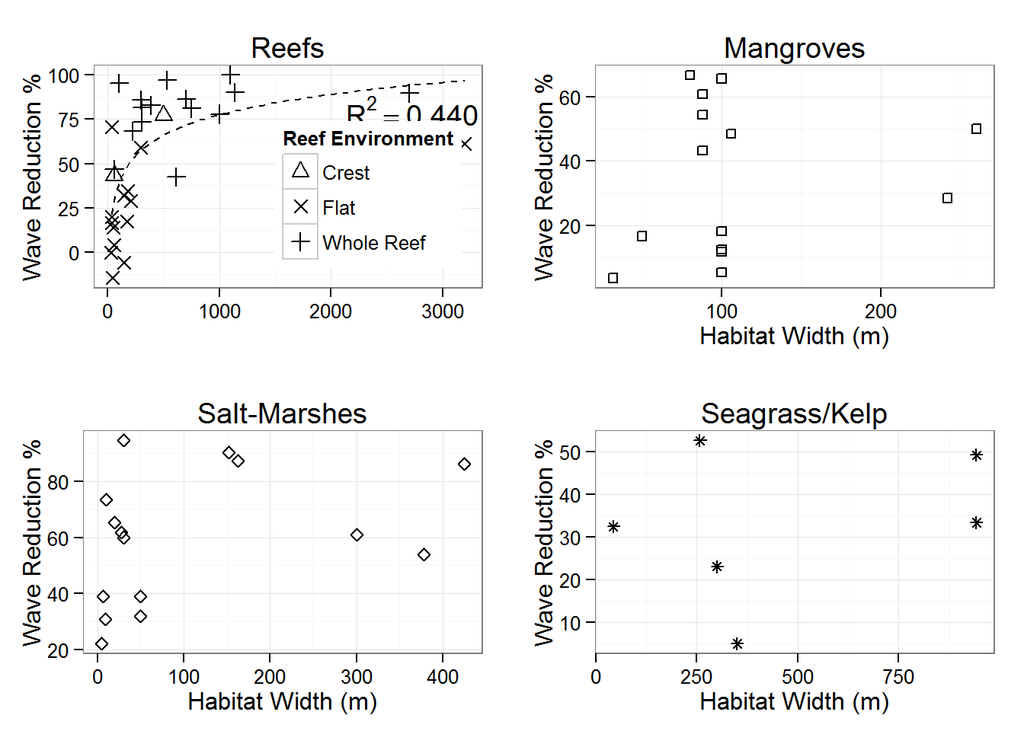

2. Wave reduction extents (absolute and %) versus incoming wave height. This first requires removal of all variables that do not report an incoming wave height.

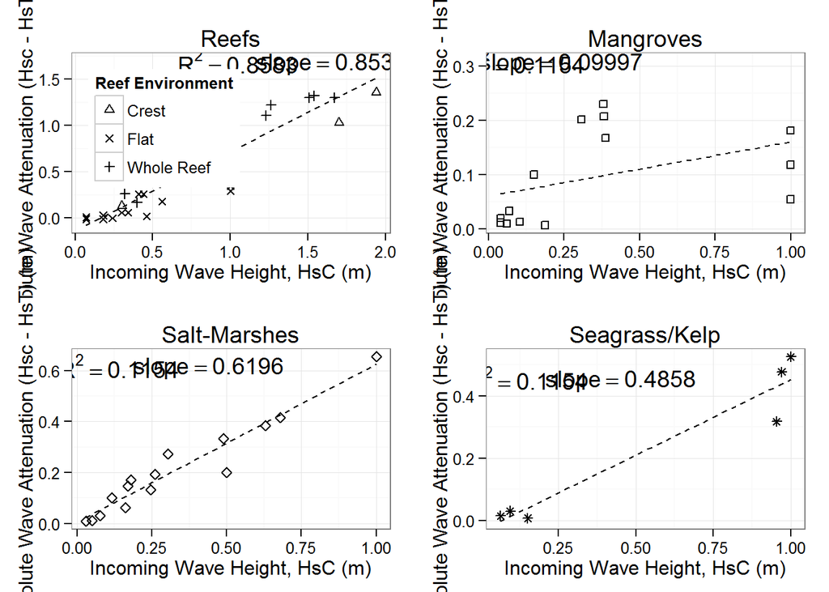

[figure not shown]

Finally we plot wave reduction versus dimensionless parameters, for specific parameters and specific habitats. These include:  
1. H/h and B/L for Reefs

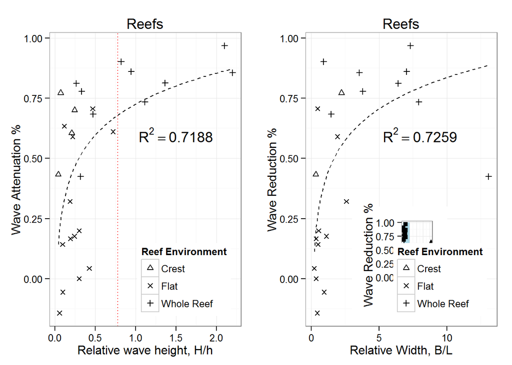

2. hv/h for salt-marshes

```
##
## Call:
## lm(formula = R ~ alpha, data = MVRdata_R_SM_sub)
##
## Residuals:
##       65       66       67       68
##  0.04698 -0.03049  0.02991 -0.04641
##
## Coefficients:
##             Estimate Std. Error t value Pr(>|t|)
## (Intercept)  0.26143    0.05697   4.589   0.0443 *
## alpha        0.48598    0.10964   4.432   0.0473 *
## ---
## Signif. codes:  0 '***' 0.001 '**' 0.01 '*' 0.05 '.' 0.1 ' ' 1
##
## Residual standard error: 0.05561 on 2 degrees of freedom
## Multiple R-squared:  0.9076, Adjusted R-squared:  0.8614
## F-statistic: 19.65 on 1 and 2 DF,  p-value: 0.04732
```

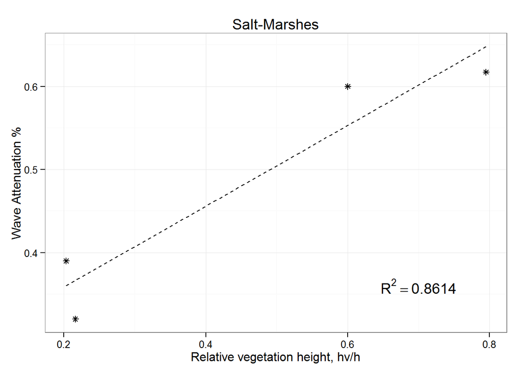

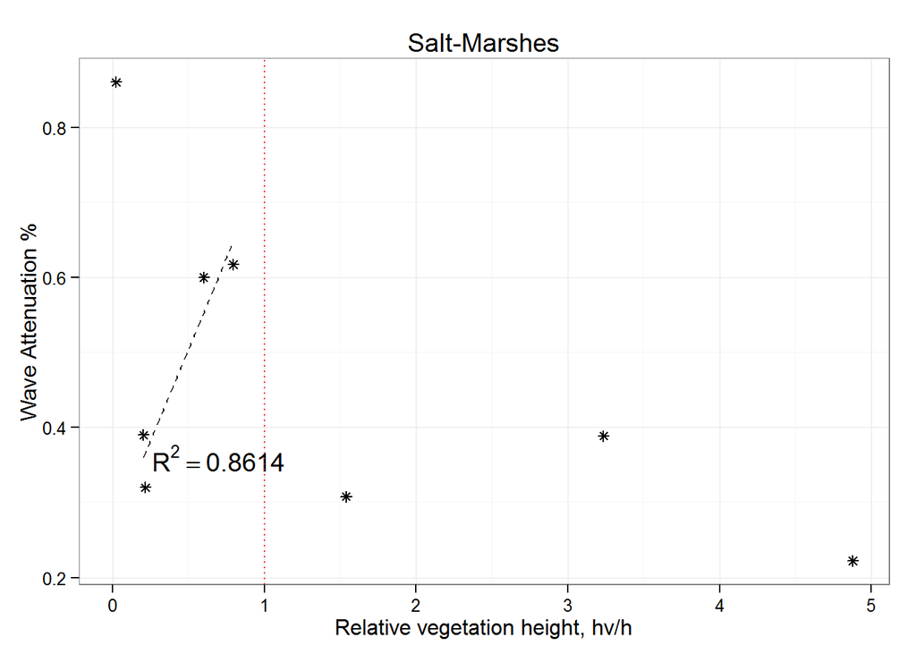

3. Other dimensionless parameter plots are also possible.

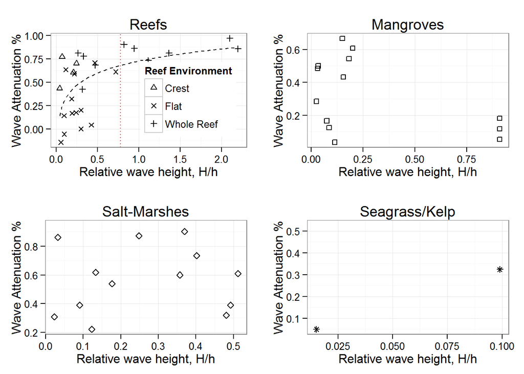

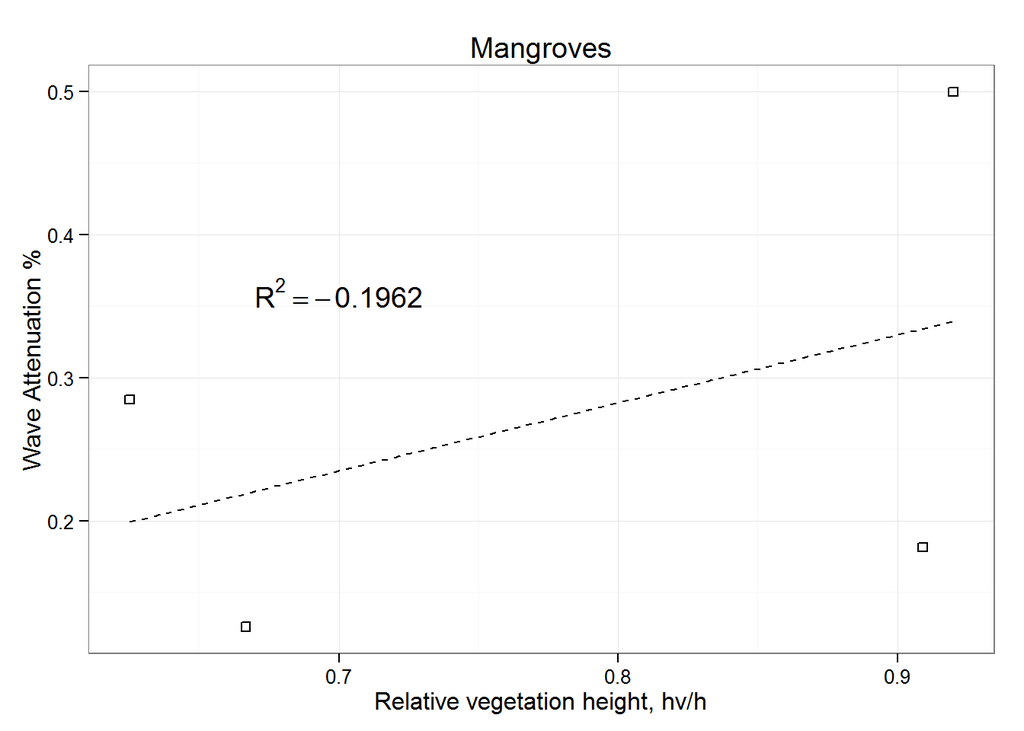

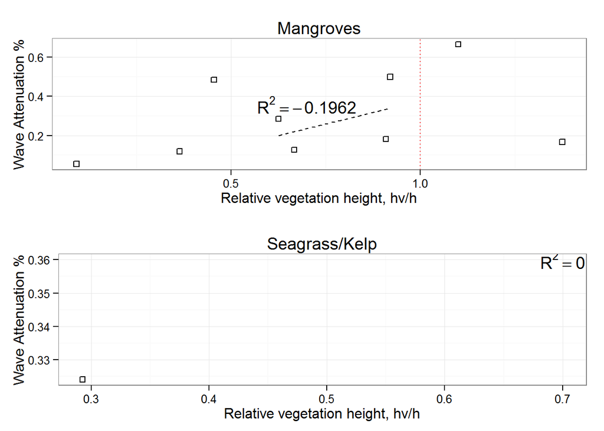

## Write Output Tables

Here we write output tables to txt files, intended as Supplemenatary Information

```r
suppltable_waves<-alldata[c("ID","First_Author","Year","Country","Habitat","Latitude","Longitude","Variable","Depth_Control","n","h","Tp","B","hv","HsC","HsT","R","Hbyh","alpha","X")]
colnames(suppltable_waves)<-c("ID","First_Author","Year","Country","Habitat","Latitude","Longitude","Variable","n","h","Tp","B","hv","Hsi","Hst","R","H/h","hv/h","B/L")
suppltable_costs<-costdata[c("ID","First_Author","Year","Country","Habitat","Latitude","Longitude","Width","Length","Area","Objective","Exposure","Habitat.Cost.Reported.Total","Cost.Year","Currency","CPI.2014","USD.2014","Habitat.Cost.USD2014","Habitat.Cost.Per.SquareMeter","Benefit.Type")]
write.table(suppltable_waves, "C:/Rfiles/SNAP/wavereductionmeasurements.txt", sep="\t",row.names=F)
write.table(suppltable_costs, "C:/Rfiles/SNAP/projectcostsandbenefits.txt", sep="\t",row.names=F)
write.table(nearbyprojects, "C:/Rfiles/SNAP/nearbyprojects.txt", sep="\t",row.names=F)
write.table(struct_comparison, "C:/Rfiles/SNAP/StructureToProjectCostRatios.txt", sep="\t",row.names=F)
write.table(meanRRvals, "C:/Rfiles/SNAP/MeanRRVals.txt", sep="\t",row.names=F)
write.table(struceffcostvals, "C:/Rfiles/SNAP/StruceffcostVals.txt", sep="\t",row.names=F)
write.table(plotdata, "C:/Rfiles/SNAP/Plotdata.txt", sep="\t",row.names=F)
write.table(bencostdata, "C:/Rfiles/SNAP/beneficialprojects.txt", sep="\t",row.names=F)
```

That’s all, folks!